# Different_threshold.2

Feiyang ZHANG

2023-04-06

`thresh.2` is a parameter of great importance. We have demonstrated that the marker gene’s specificity and the expression levels are negatively correlated. Here is the script showing the usage and the results of `thresh.2` .

# 1 load and Process Brain Data

we use PFC data, and use different `thresh.2` to exhibit the ability of starTracer

Idents of Seurat should are set to be `sub_clust` . We here will use a subset of the PFC data: projection neurons (PN), as the analysis object.

```r
snRNA_PN <- snRNA.hpfc.sct[,snRNA.hpfc.sct$bio_clust %in% "PN"]
```

process the object snRNA_PN

```r
snRNA_PN <- FindVariableFeatures(snRNA_PN, nfeatures = 3000)
snRNA_PN <- NormalizeData(snRNA_PN) %>% ScaleData()
snRNA_PN <- RunPCA(snRNA_PN)
```

find PC numer

```r
num <- FindPCNum(snRNA_PN)
num
```

[output not shown]

RunUMAP

```r
snRNA_PN <- RunUMAP(snRNA_PN,dims = num)
```

DimPlot of the dataset after processing:

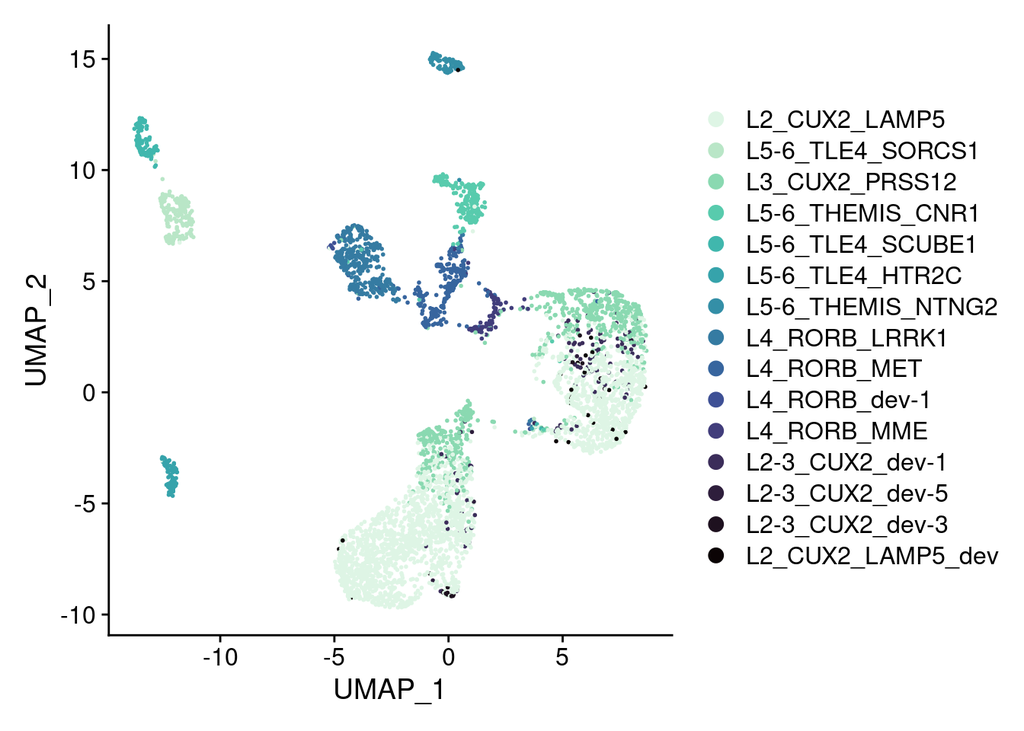

```r
Idents(snRNA_PN) <- snRNA_PN$sub_clust
(p <- DimPlot(snRNA_PN,cols = rev(viridis::mako(length(unique(snRNA_PN$sub_clust))))))
```

# 2 different Threshold of thresh.2

## 2.1 thresh.2=0, gene.use=all

With `thresh.2=0`, starTracer will NOT filter out any gene. The specificity of marker genes we found will reach the highest level. Setting gene.use to all, starTracer will identify marker genes from all the genes included, not just the high variable genes.

```r
star.thresh0 <- starTracer::searchMarker(snRNA_PN,thresh.1 = 0.5,thresh.2 = 0,num = 2,gene.use = NULL)
```

```
## using L2_CUX2_LAMP5, L5-6_TLE4_SORCS1, L3_CUX2_PRSS12, L5-6_THEMIS_CNR1, L5-6_TLE4_SCUBE1, L5-6_TLE4_HTR2C, L5-6_THEMIS_NTNG2, L4_RORB_LRRK1, L4_RORB_MET, L4_RORB_dev-1, L4_RORB_MME, L2-3_CUX2_dev-1, L2-3_CUX2_dev-5, L2-3_CUX2_dev-3, L2_CUX2_LAMP5_dev as ident...
```

```
## using all genes as input features...
```

```
## max normalizing the matirx...
```

```
## screen genes in each cluster according to thresh.2
```

```
## calculating parameters...
```

```
## Using "RNA" as the assay to plot Heatmap...
```

```
## createing out put data...
```

```
## Analysing Complete!
```

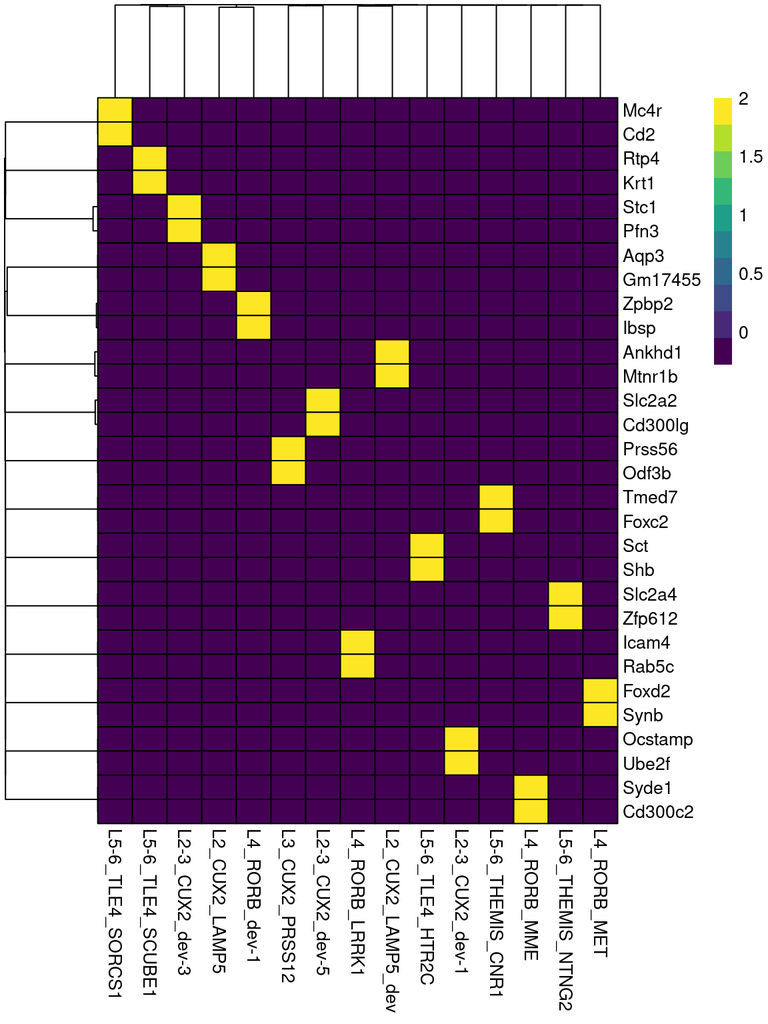

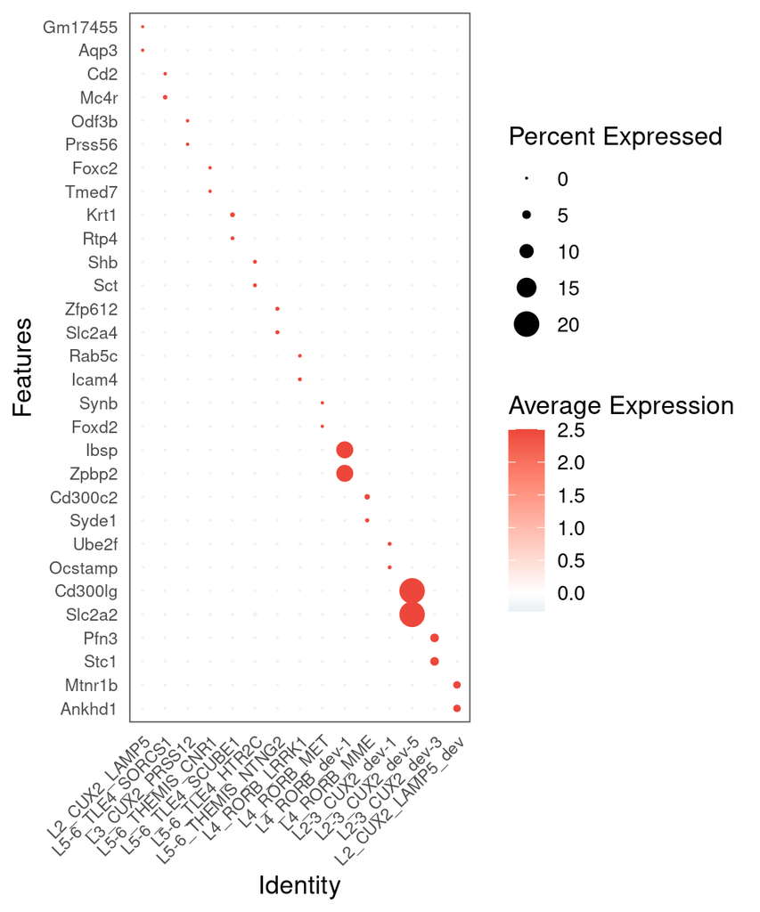

```r
(p <- use_dotplot(snRNA_PN,features = star.thresh0$genes.markers, colors.gradient = c("#018daa","#ffffff","#ed463a")))
```

histogram showing the specificity level of the marker genes, we can notice an enrichment in 1 (100%).

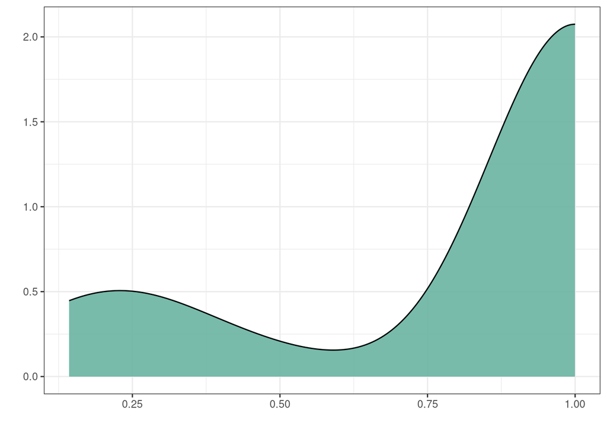

```r
frame.star.thresh0 <- subset(star.thresh0$para_frame,star.thresh0$para_frame$gene %in% star.thresh0$genes.markers)[,c("max.X","gene")]
colnames(frame.star.thresh0)[1] <- "cluster"
frame.star.thresh0 <- cal_spe(snRNA_PN,ident.use = "sub_clust",frame.star.thresh0)
(p <- ggplot(data=frame.star.thresh0, aes(x = pct.pos)) +
  geom_density(binwidth = 0.1,fill = "#69b3a2",
                 color = "black", alpha=0.9) + theme_bw() + labs(x="",y=""))
```

expression level

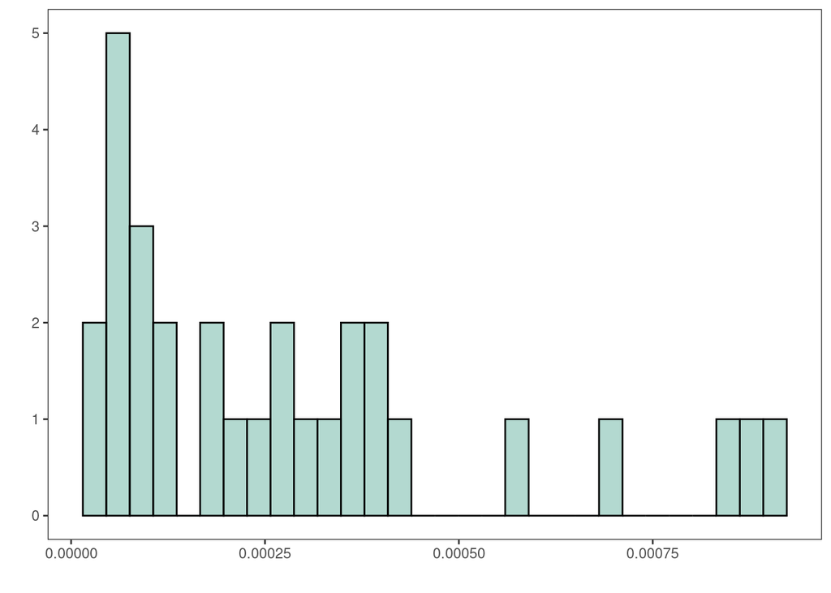

```r
expr.thresh0 <- snRNA_PN@assays$RNA@data[star.thresh0$genes.markers,] %>% rowMeans() %>% as.data.frame()
colnames(expr.thresh0) <- "expr"
(p <- ggplot(data=expr.thresh0, aes(x = expr)) +
  geom_histogram(fill = "#69b3a2",color = "black",alpha = 0.5) + theme_bw() + labs(x="",y="") + theme(panel.grid = element_blank()))
```

## 2.2 thresh2 = 0.2, gene.use = all

```r
star.thresh02 <- starTracer::searchMarker(snRNA_PN,thresh.1 = 0.5,thresh.2 = 0.2,num = 2,gene.use = NULL)
```

```
## using L2_CUX2_LAMP5, L5-6_TLE4_SORCS1, L3_CUX2_PRSS12, L5-6_THEMIS_CNR1, L5-6_TLE4_SCUBE1, L5-6_TLE4_HTR2C, L5-6_THEMIS_NTNG2, L4_RORB_LRRK1, L4_RORB_MET, L4_RORB_dev-1, L4_RORB_MME, L2-3_CUX2_dev-1, L2-3_CUX2_dev-5, L2-3_CUX2_dev-3, L2_CUX2_LAMP5_dev as ident...
```

```
## using all genes as input features...
```

```
## max normalizing the matirx...
```

```
## screen genes in each cluster according to thresh.2
```

```
## calculating parameters...
```

```
## Using "RNA" as the assay to plot Heatmap...
```

```
## createing out put data...
```

```
## Analysing Complete!
```

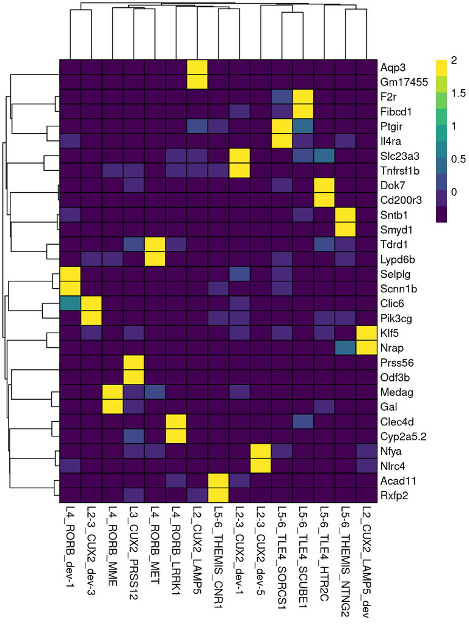

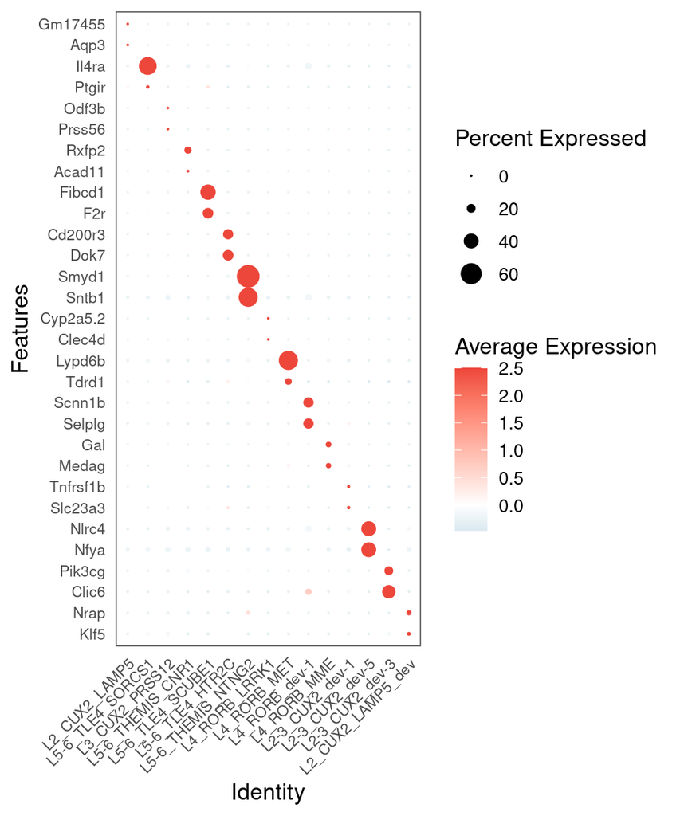

```r
(p <- use_dotplot(snRNA_PN,features = star.thresh02$genes.markers, colors.gradient = c("#018daa","#ffffff","#ed463a")))
```

histogram:

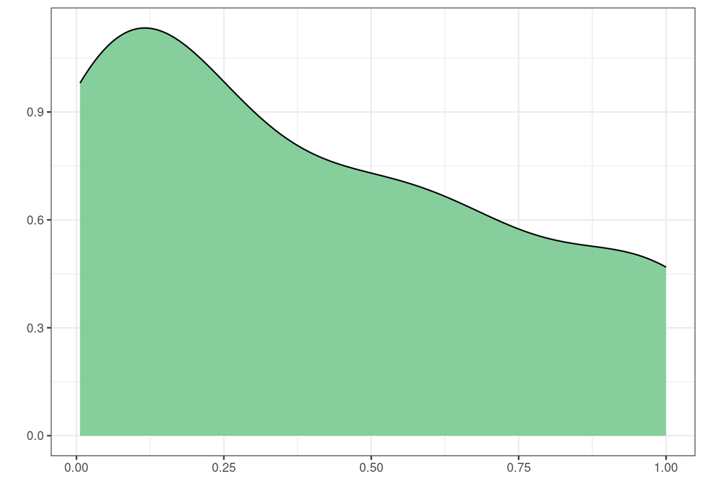

```r
frame.star.thresh02 <- subset(star.thresh02$para_frame,star.thresh02$para_frame$gene %in% star.thresh02$genes.markers)[,c("max.X","gene")]
colnames(frame.star.thresh02)[1] <- "cluster"
frame.star.thresh02 <- cal_spe(snRNA_PN,ident.use = "sub_clust",frame.star.thresh02)
(p <- ggplot(data=frame.star.thresh02, aes(x = pct.pos)) +
  geom_density(binwidth = 0.1,fill = "#79c890",
                 color = "black", alpha=0.9) + theme_bw() + labs(x="",y=""))
```

expression level

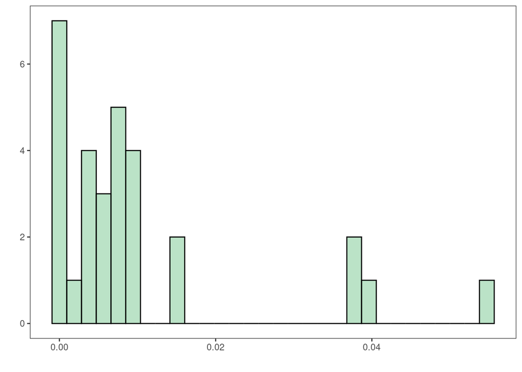

```r
expr.thresh02 <- snRNA_PN@assays$RNA@data[star.thresh02$genes.markers,] %>% rowMeans() %>% as.data.frame()
colnames(expr.thresh02) <- "expr"
(p <- ggplot(data=expr.thresh02, aes(x = expr)) +
  geom_histogram(fill = "#79c890",color = "black",alpha = 0.5) + theme_bw() + labs(x="",y="") + theme(panel.grid = element_blank()))
```

## 2.3 thresh2 = 0.4, gene.use = all

```r
star.thresh04 <- starTracer::searchMarker(snRNA_PN,thresh.1 = 0.5,thresh.2 = 0.4,num = 2,gene.use = NULL)
```

```
## using L2_CUX2_LAMP5, L5-6_TLE4_SORCS1, L3_CUX2_PRSS12, L5-6_THEMIS_CNR1, L5-6_TLE4_SCUBE1, L5-6_TLE4_HTR2C, L5-6_THEMIS_NTNG2, L4_RORB_LRRK1, L4_RORB_MET, L4_RORB_dev-1, L4_RORB_MME, L2-3_CUX2_dev-1, L2-3_CUX2_dev-5, L2-3_CUX2_dev-3, L2_CUX2_LAMP5_dev as ident...
```

```
## using all genes as input features...
```

```
## max normalizing the matirx...
```

```
## screen genes in each cluster according to thresh.2
```

```
## calculating parameters...
```

```
## Using "RNA" as the assay to plot Heatmap...
```

```
## createing out put data...
```

```
## Analysing Complete!
```

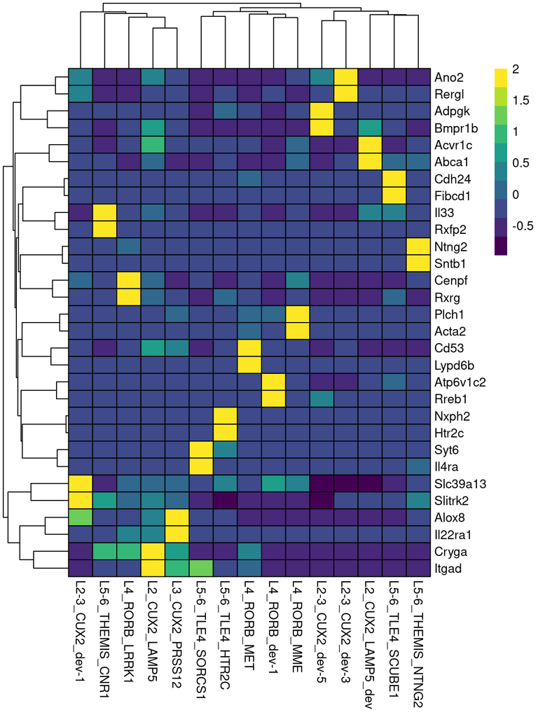

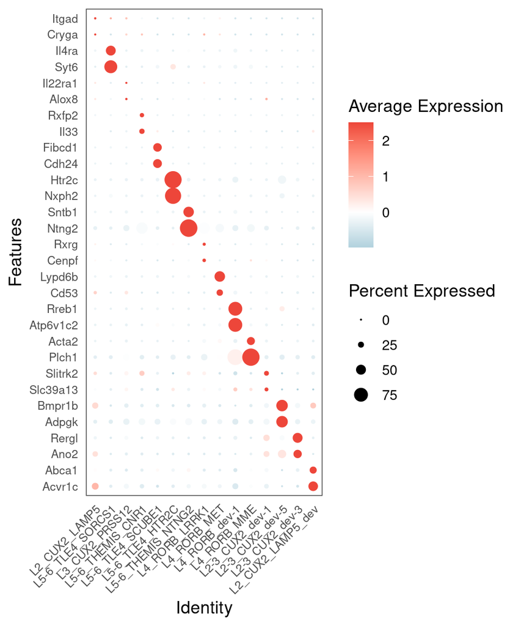

```r
(p <- use_dotplot(snRNA_PN,features = star.thresh04$genes.markers, colors.gradient = c("#018daa","#ffffff","#ed463a")))
```

histogram

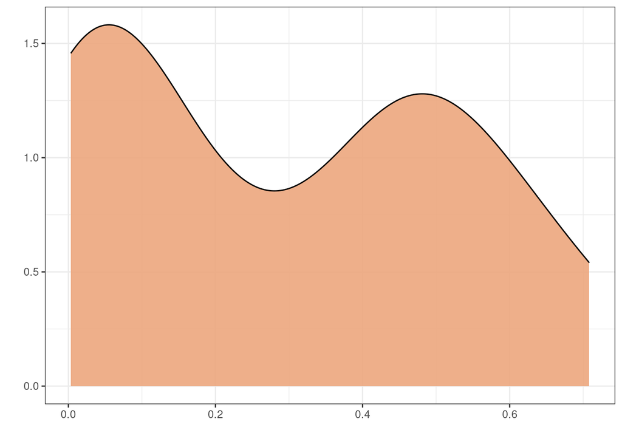

```r
frame.star.thresh04 <- subset(star.thresh04$para_frame,star.thresh04$para_frame$gene %in% star.thresh04$genes.markers)[,c("max.X","gene")]
colnames(frame.star.thresh04)[1] <- "cluster"
frame.star.thresh04 <- cal_spe(snRNA_PN,ident.use = "sub_clust",frame.star.thresh04)
(p <- ggplot(data=frame.star.thresh04, aes(x = pct.pos)) +
  geom_density(binwidth = 0.1,fill = "#eca67d",
                 color = "black", alpha=0.9) + theme_bw() + labs(x="",y=""))
```

expression level

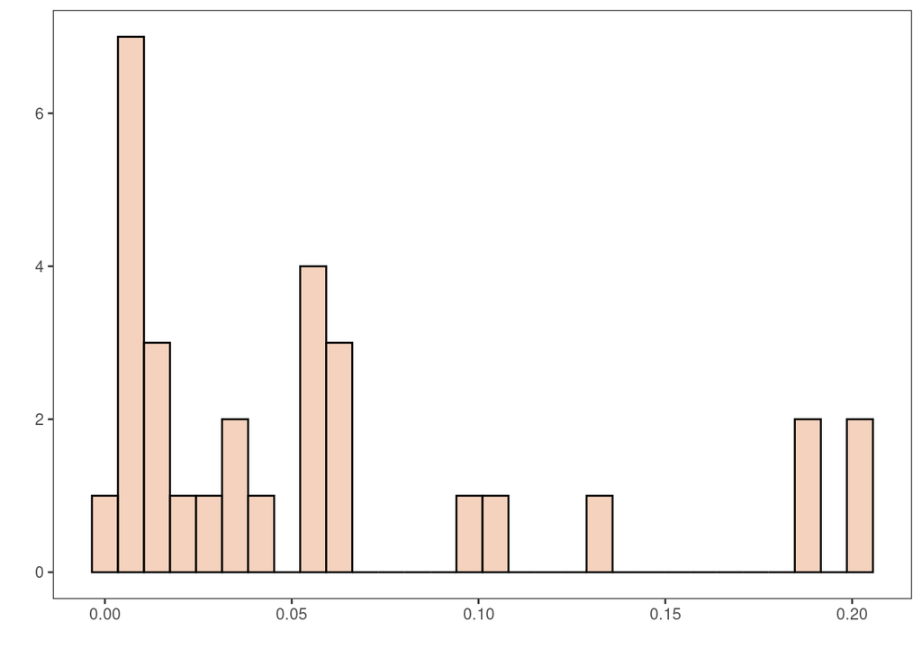

```r
expr.thresh04 <- snRNA_PN@assays$RNA@data[star.thresh04$genes.markers,] %>% rowMeans() %>% as.data.frame()
colnames(expr.thresh04) <- "expr"
(p <- ggplot(data=expr.thresh04, aes(x = expr)) +
  geom_histogram(fill = "#eca67d",color = "black",alpha = 0.5) + theme_bw() + labs(x="",y="") + theme(panel.grid = element_blank()))
```

## 2.4 thresh2 = 0.6, gene.use = all

```r
star.thresh06 <- starTracer::searchMarker(snRNA_PN,thresh.1 = 0.5,thresh.2 = 0.6,num = 2,gene.use = NULL)
```

```
## using L2_CUX2_LAMP5, L5-6_TLE4_SORCS1, L3_CUX2_PRSS12, L5-6_THEMIS_CNR1, L5-6_TLE4_SCUBE1, L5-6_TLE4_HTR2C, L5-6_THEMIS_NTNG2, L4_RORB_LRRK1, L4_RORB_MET, L4_RORB_dev-1, L4_RORB_MME, L2-3_CUX2_dev-1, L2-3_CUX2_dev-5, L2-3_CUX2_dev-3, L2_CUX2_LAMP5_dev as ident...
```

```
## using all genes as input features...
```

```
## max normalizing the matirx...
```

```
## screen genes in each cluster according to thresh.2
```

```
## calculating parameters...
```

```
## Using "RNA" as the assay to plot Heatmap...
```

```
## createing out put data...
```

```
## Analysing Complete!
```

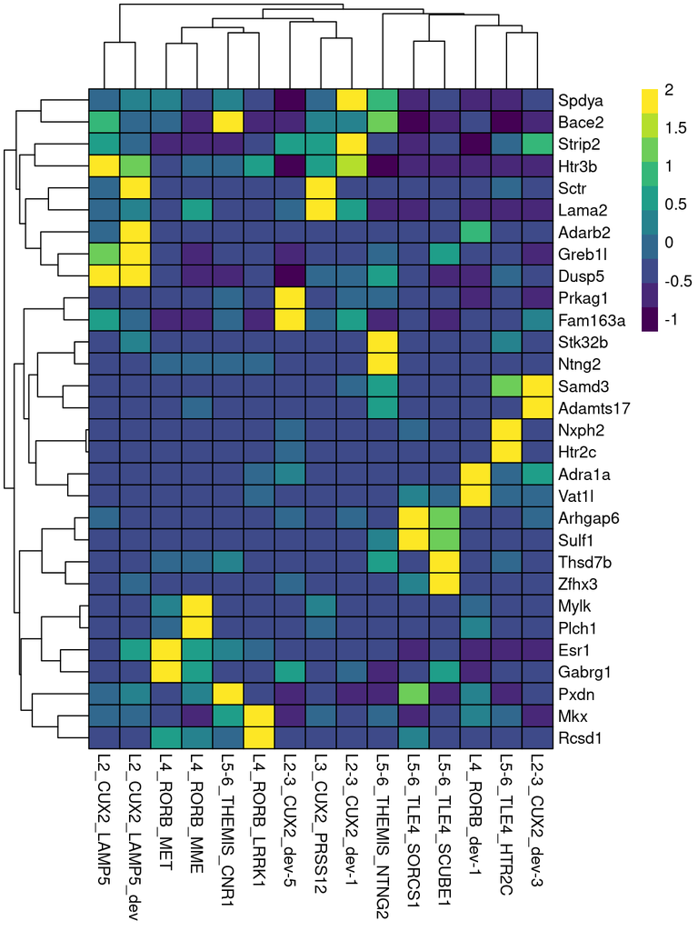

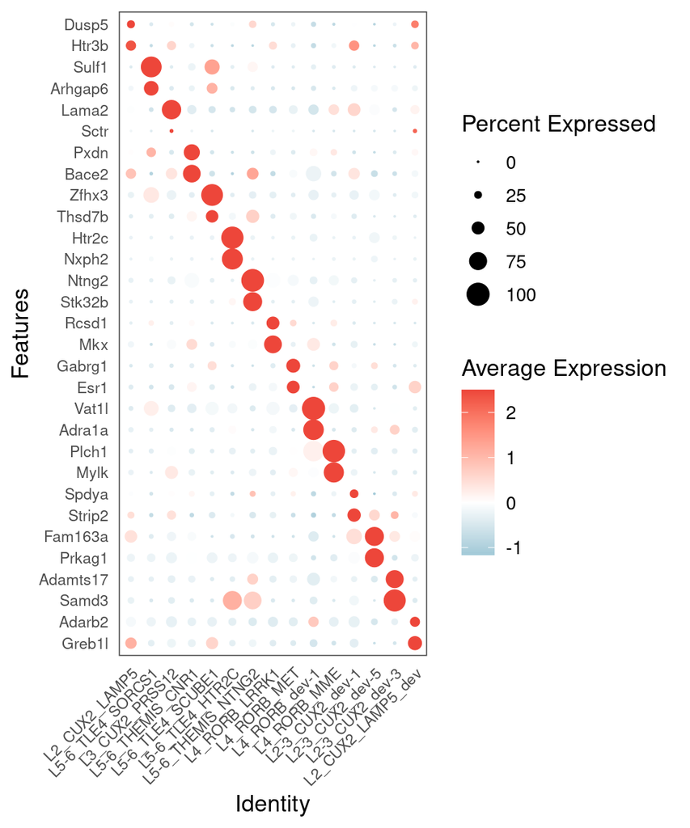

```r
(p <- use_dotplot(snRNA_PN,features = star.thresh06$genes.markers, colors.gradient = c("#018daa","#ffffff","#ed463a")))
```

histogram

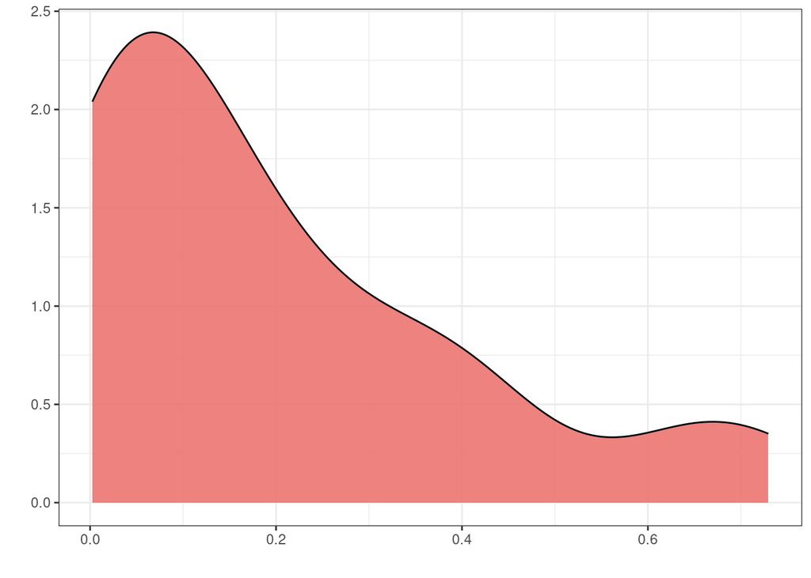

```r
frame.star.thresh06 <- subset(star.thresh06$para_frame,star.thresh06$para_frame$gene %in% star.thresh06$genes.markers)[,c("max.X","gene")]
colnames(frame.star.thresh06)[1] <- "cluster"
frame.star.thresh06 <- cal_spe(snRNA_PN,ident.use = "sub_clust",frame.star.thresh06)
(p <- ggplot(data=frame.star.thresh06, aes(x = pct.pos)) +
  geom_density(binwidth = 0.1,fill = "#eb7471",
                 color = "black", alpha=0.9) + theme_bw() + labs(x="",y=""))
```

expression level

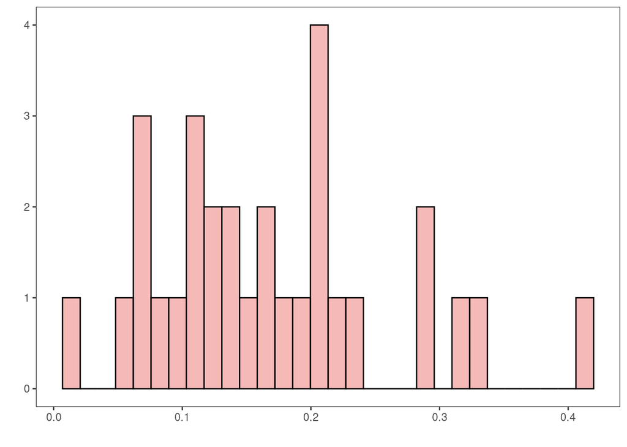

```r
expr.thresh06 <- snRNA_PN@assays$RNA@data[star.thresh06$genes.markers,] %>% rowMeans() %>% as.data.frame()
colnames(expr.thresh06) <- "expr"
(p <- ggplot(data=expr.thresh06, aes(x = expr)) +
  geom_histogram(fill = "#eb7471",color = "black",alpha = 0.5) + theme_bw() + labs(x="",y="") + theme(panel.grid = element_blank()))
```

## 2.5 thresh2 = 0.8, gene.use = all

```r
star.thresh08 <- starTracer::searchMarker(snRNA_PN,thresh.1 = 0.5,thresh.2 = 0.8,num = 2,gene.use = NULL)
```

```
## using L2_CUX2_LAMP5, L5-6_TLE4_SORCS1, L3_CUX2_PRSS12, L5-6_THEMIS_CNR1, L5-6_TLE4_SCUBE1, L5-6_TLE4_HTR2C, L5-6_THEMIS_NTNG2, L4_RORB_LRRK1, L4_RORB_MET, L4_RORB_dev-1, L4_RORB_MME, L2-3_CUX2_dev-1, L2-3_CUX2_dev-5, L2-3_CUX2_dev-3, L2_CUX2_LAMP5_dev as ident...
```

```
## using all genes as input features...
```

```
## max normalizing the matirx...
```

```
## screen genes in each cluster according to thresh.2
```

```
## calculating parameters...
```

```
## Using "RNA" as the assay to plot Heatmap...
```

```
## createing out put data...
```

```
## Analysing Complete!
```

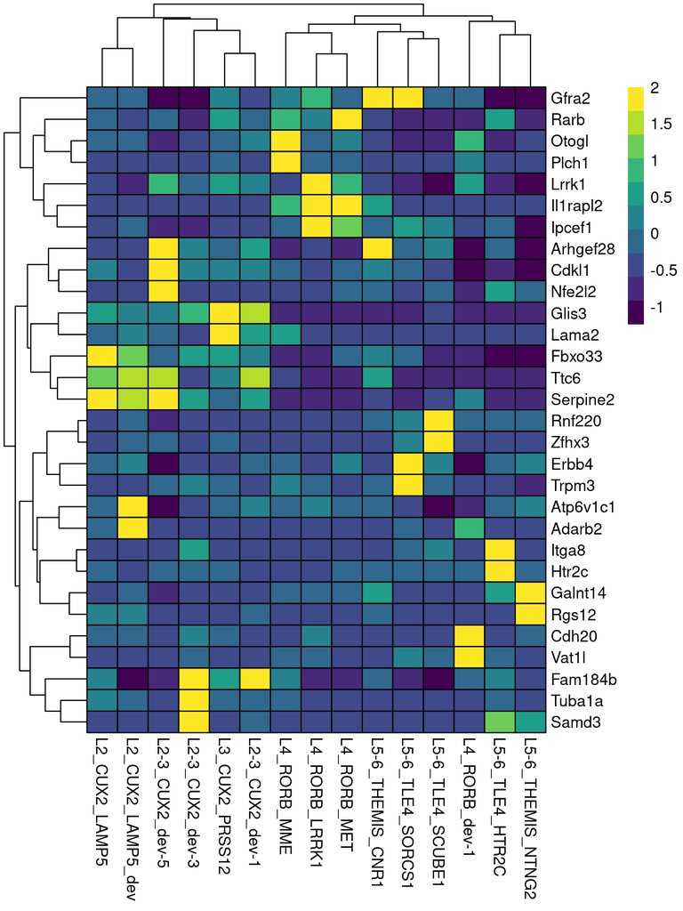

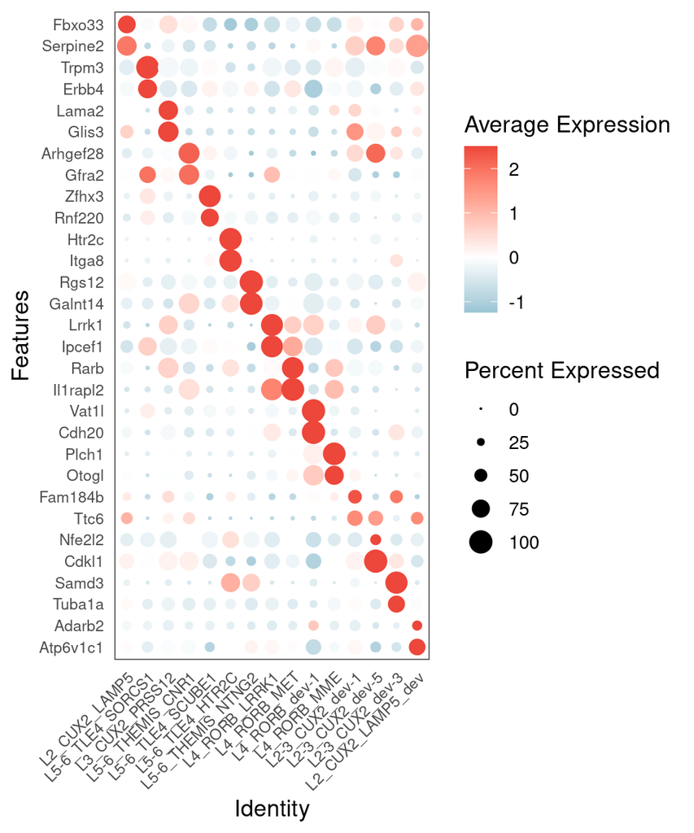

```r
(p <- use_dotplot(snRNA_PN,features = star.thresh08$genes.markers, colors.gradient = c("#018daa","#ffffff","#ed463a")))
```

histogram

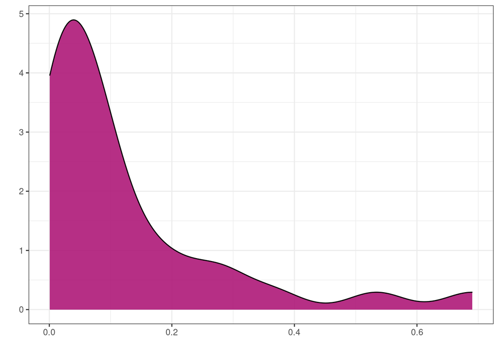

```r
frame.star.thresh08 <- subset(star.thresh08$para_frame,star.thresh08$para_frame$gene %in% star.thresh08$genes.markers)[,c("max.X","gene")]
colnames(frame.star.thresh08)[1] <- "cluster"
frame.star.thresh08 <- cal_spe(snRNA_PN,ident.use = "sub_clust",frame.star.thresh08)
(p <- ggplot(data=frame.star.thresh08, aes(x = pct.pos)) +
  geom_density(binwidth = 0.1,fill = "#ae1978",
                 color = "black", alpha=0.9) + theme_bw() + labs(x="",y=""))
```

expression level

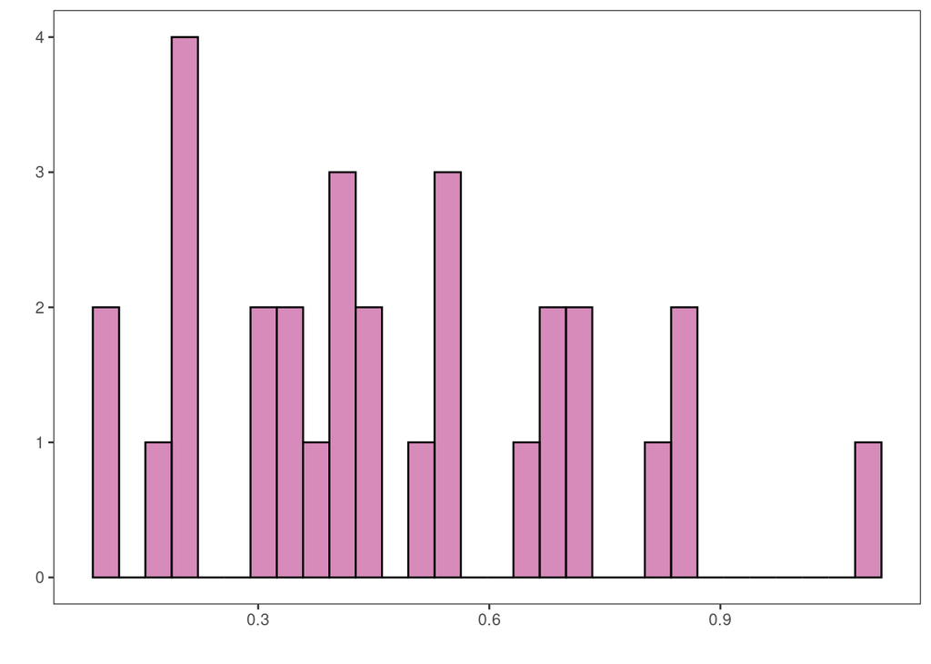

```r
expr.thresh08 <- snRNA_PN@assays$RNA@data[star.thresh08$genes.markers,] %>% rowMeans() %>% as.data.frame()
colnames(expr.thresh08) <- "expr"
(p <- ggplot(data=expr.thresh08, aes(x = expr)) +
  geom_histogram(fill = "#ae1978",color = "black",alpha = 0.5) + theme_bw() + labs(x="",y="") + theme(panel.grid = element_blank()))
```

# 3 Put all the density plot together

## 3.1 Specificity: Density Plot

The distribution of the specificity in all samples.

```r
mat.expre.spe <- data.frame(thresh0 = frame.star.thresh0$pct.pos,
                               thresh02 = frame.star.thresh02$pct.pos,
                               thresh04 = frame.star.thresh04$pct.pos,
                               thresh06 = frame.star.thresh06$pct.pos,
                               thresh08 = frame.star.thresh08$pct.pos)
colnames(mat.expre.spe) <- c("thresh0","thresh02","thresh04","thresh06","thresh08")
mat.expre.spe <- reshape2::melt(mat.expre.spe)
head(mat.expre.spe)
```

```
##   variable value
## 1  thresh0     1
## 2  thresh0     1
## 3  thresh0     1
## 4  thresh0     1
## 5  thresh0     1
## 6  thresh0     1
```

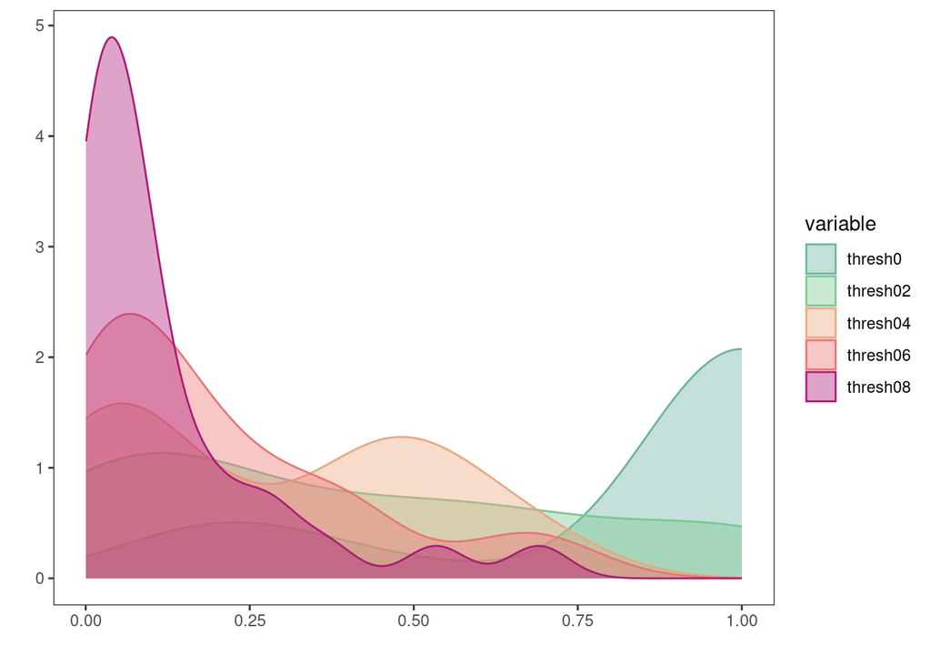

```r
(p <- ggplot(data = mat.expre.spe) +
  geom_density(aes(x = value, fill = variable, color = variable), alpha = 0.4) +
  theme_bw() + labs(x="",y="") + theme(panel.grid = element_blank()) +
  scale_fill_manual(values = c("#69b3a2","#79c890","#eca67d","#eb7471","#ae1978")) +
  scale_color_manual(values = c("#69b3a2","#79c890","#eca67d","#eb7471","#ae1978")))
```

```r
mat.expre.thresh <- data.frame(thresh0 = expr.thresh0,
                               thresh02 = expr.thresh02,
                               thresh04 = expr.thresh04,
                               thresh06 = expr.thresh06,
                               thresh08 = expr.thresh08)
colnames(mat.expre.thresh) <- c("thresh0","thresh02","thresh04","thresh06","thresh08")
mat.expre.thresh <- reshape2::melt(mat.expre.thresh)
head(mat.expre.thresh)
```

```
##   variable        value
## 1  thresh0 3.213416e-04
## 2  thresh0 1.959860e-04
## 3  thresh0 8.632410e-04
## 4  thresh0 9.931124e-05
## 5  thresh0 6.863646e-04
## 6  thresh0 4.294552e-04
```

## 3.2 Specificity: Line Plot

```r
mat.pct.pos.thresh <- data.frame(thresh0 = frame.star.thresh0$pct.pos,
                                 thresh02 = frame.star.thresh02$pct.pos,
                                 thresh04 = frame.star.thresh04$pct.pos,
                                 thresh06 = frame.star.thresh06$pct.pos,
                                 thresh08 = frame.star.thresh08$pct.pos)
colnames(mat.pct.pos.thresh) <- c("thresh0","thresh02","thresh04","thresh06","thresh08")
mat.pct.pos.thresh <- reshape2::melt(mat.pct.pos.thresh)
mat.pct.pos.thresh <- Rmisc::summarySE(mat.pct.pos.thresh, measurevar = "value", groupvar = c("variable"))
```

plot

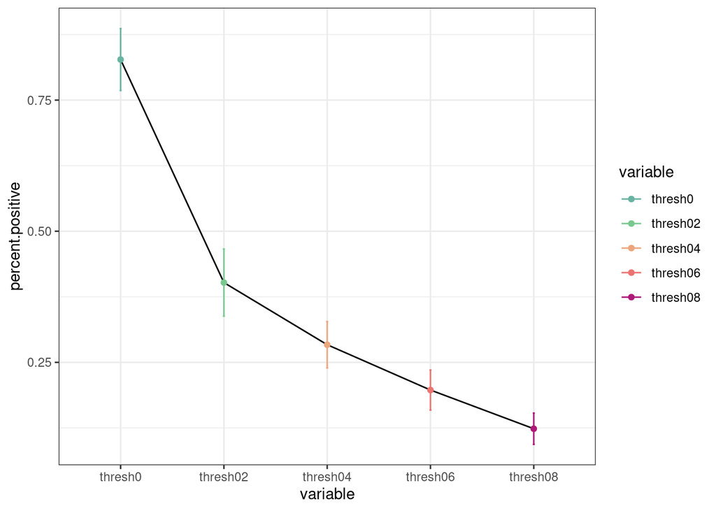

```r
(p <- ggplot(data = mat.pct.pos.thresh) +
  geom_errorbar(aes(x = variable,y = value, ymin = value - se, ymax = value + se, color = variable), width = 0.02) +
  geom_line(aes(x = variable,y = value, group = 1),color = "black",lwd = 0.5) +
  geom_point(aes(x = variable,y = value, color = variable)) +
  scale_color_manual(values = c("#69b3a2","#79c890","#eca67d","#eb7471","#ae1978")) +
  theme_bw() + ylab("percent.positive"))
```

## 3.3 Mean Expression Level

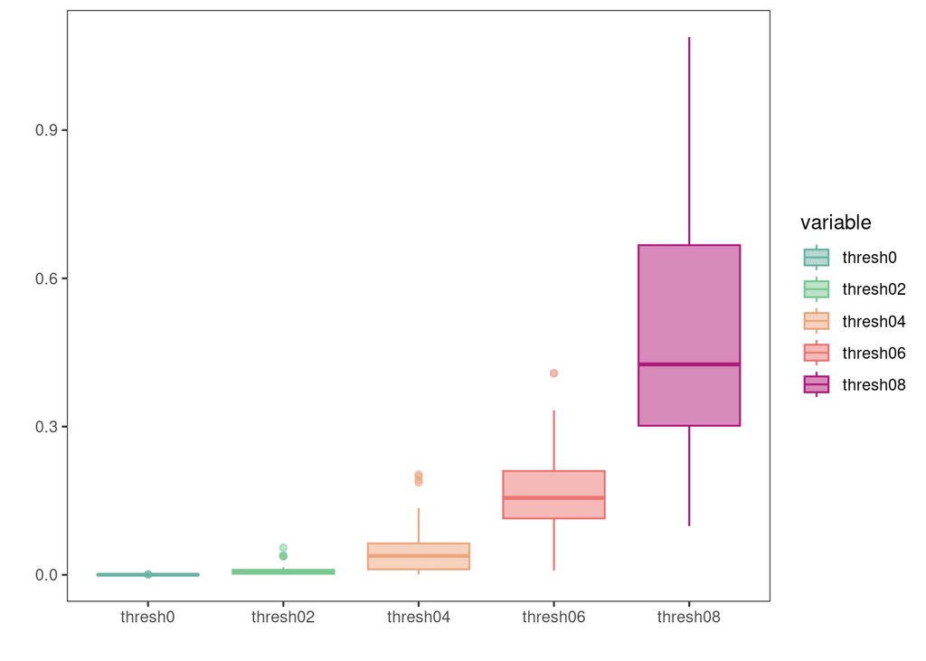

```r
(p <- ggplot(data=mat.expre.thresh) +
  geom_boxplot(aes(x = variable,y = value,fill = variable, color = variable),alpha = 0.5) + theme_bw() + labs(x="",y="") + theme(panel.grid = element_blank()) +
  scale_fill_manual(values = c("#69b3a2","#79c890","#eca67d","#eb7471","#ae1978")) +
  scale_color_manual(values = c("#69b3a2","#79c890","#eca67d","#eb7471","#ae1978")))
```